# Fine scale velocity exploration for water quality drought synthesis

## Velocity with WY index across stations

Across all water years, mean net velocity is most always positive at Cache and Jersey but only positive in the wet seasons of wet years at the Middle and Old River stations. For much of the year, the export pumps create net landward velocities in Middle and Old Rivers that is demonstrated by negative velocities. Only during the wet season of wet years does increased freshwater flow overcome the effects of the pumps and create net positive velocities.

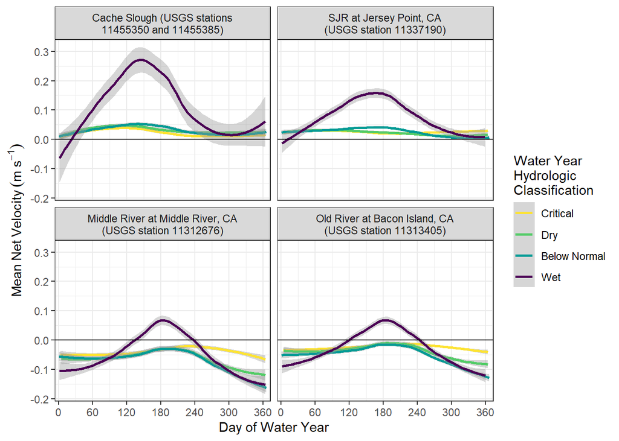

```r
plt_mean_net_vel_wyday <- vel_weekly_c %>%
  ggplot(aes(x = WYday, y = MeanNetVel, color = YearType)) +
  geom_smooth() +
  color_pal_yrtype(aes_type = "color", scale_title = "Water Year\nHydrologic\nClassification") +
  facet_wrap(vars(Station)) +
  geom_hline(yintercept = 0, linetype = "solid", col = "black") +
  scale_x_continuous(
    name = "Day of Water Year",
    breaks = seq.int(0, 360, by = 60),
    expand = expansion(mult = 0.02)
  ) +
  ylab(expression(Mean~Net~Velocity~(m~s^{-1}))) +
  theme_bw()

plt_mean_net_vel_wyday
```

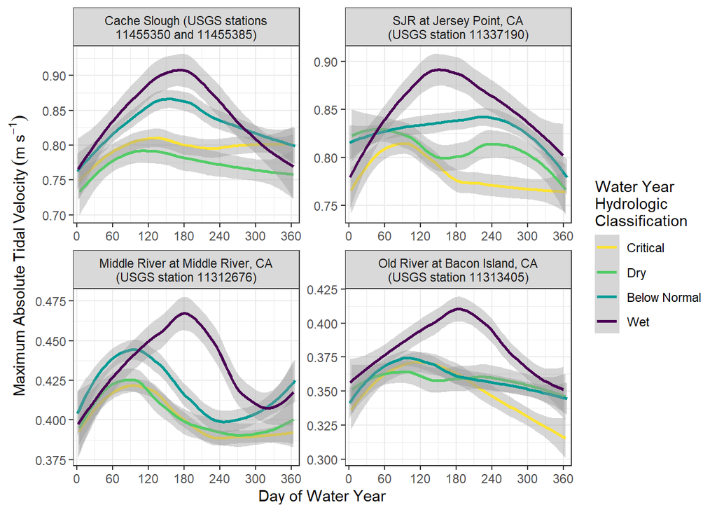

```r
plt_max_abs_tidal_vel_wyday <- vel_weekly_c %>%
  ggplot(aes(x = WYday, y = MaxAbsTidalVel, color = YearType)) +
  geom_smooth() +
  color_pal_yrtype(aes_type = "color", scale_title = "Water Year\nHydrologic\nClassification") +
  facet_wrap(vars(Station), scales = "free") +
  scale_x_continuous(
    name = "Day of Water Year",
    breaks = seq.int(0, 360, by = 60),
    expand = expansion(mult = 0.02)
  ) +
  ylab(expression(Maximum~Absolute~Tidal~Velocity~(m~s^{-1}))) +
  theme_bw()

plt_max_abs_tidal_vel_wyday
```

```r
# Combine figures into one multipanel figure
plt_vel_wyday <- plt_mean_net_vel_wyday / plt_max_abs_tidal_vel_wyday +
  plot_annotation(tag_levels = "A") +
  plot_layout(guides = "collect")
```

# Export Figures

```r
# Define file path for manuscript figures
fp_plots <- here("results/figures")

# Velocity vs Outflow Figure
ggsave(
  file.path(fp_plots, "vel_vs_outflow.jpg"),
  plot = plt_vel_vs_outflow,
  width = 7,
  height = 9,
  units = "in",
  dpi = 300
)

# Delta Outflow by WY day of year Figure
ggsave(
  file.path(fp_plots, "outflow_wyday.jpg"),
  plot = plt_outflow_wyday,
  width = 5,
  height = 3,
  units = "in",
  dpi = 300
)

# Velocity by WY day of year Figure
ggsave(
  file.path(fp_plots, "vel_wyday.jpg"),
  plot = plt_vel_wyday,
  width = 7,
  height = 9,
  units = "in",
  dpi = 300
)
```